# Spatial dynamic of the biomes through the Holocene

Vincent Pellissier

29 août 2018

While organizing a workshop on the impact of human activities on biodiversity at different spatial scales, I realized that a good entry point would be to illustrate how some physical features of the environment (for example biome area, as defined as the area of a biome not being covered by land-use) have changed through time. What is presented is a walkthrough on the process used to generate biome extent maps through time and the visual representation of it. The code (functions and analyses scripts) is [available here](https://github.com/vpellissier/holocene_biomes_dynamics) and the data generated are [downloadable here](https://drive.google.com/open?id=13hO1e9_K6_Dz0mURGzLI7ADpASQE4QdV). The aim of the code presented here was to illustrate the variation of the extent and total area of biomes through time that is due to human activities. I had two outputs in mind: (1) a series of chronological maps showing the variation of the extent of each biome not being affected by human through time and (2) a temporal graph of the total area of each biome not being affected by human. In order to do it, I use the past land-use dataset [HYDE 3.2 dataset](https://easy.dans.knaw.nl/ui/datasets/id/easy-dataset:67445/tab/1) to compile for each point in time the amount of each cell covered by a human land-cover (grazing or cropland), allowing me to compute the spatial extent of each biome - *i.e.* how many cells in a biome are mostly covered by non human land-cover - and the total area of each biome at each point in time.

# 1 The historical land-use dataset

The [HYDE 3.2 dataset](https://easy.dans.knaw.nl/ui/datasets/id/easy-dataset:67445/tab/1) is a well-known reconstruction of past land-use (since the beginning of the Holocene). For each time point the percentage of each cell being cropland (divided into irrigated and rain-fed non-rice crops and irrigated and rain-fed rice crops) or grazing land (divided into intensive pasture and less intensive rangeland) is modelled based on population estimates. The whole data set comprises 66 series of maps: for each time point, a map for each of the above land-cover is produced. In addition, at each time point, three different population estimates are used (lower, median and upper)

# 2 Methods

On the HYDE website, maps are downloadable either one by one (that is, for each point in time, one has to select the desired population scenario, format, date and type of land-cover) or in bulk (that is, on .zip file per date). Neither of these options is really practical. The first one implies clicking on each map, one by one. The second one implies extracting the maps from the zipfile, either one by one, or automatically (and having more information that is really needed). To overcome that issue, I designed a function `compute_non_human()` that scraps maps from the website for a given point in time, computes the percentage of each cell NOT covered by a human land-cover (i.e. cropland and grazing land) for each biome and saves the resulting rasters on a local computer.

## 2.1 Download and computation algorithm

The code in the function is commented, but what follow is a brief description of the algorithm and the code used to run the function:

```r
library(raster, quietly = T, warn.conflicts = F)
library(snowfall, quietly = T, warn.conflicts = F)
require(dplyr, quietly = T, warn.conflicts = F)
library(tibble, quietly = T, warn.conflicts = F)
library(rasterVis, quietly = T, warn.conflicts = F)
library(ggplot2, quietly = T, warn.conflicts = F)
library(tidyr, quietly = T, warn.conflicts = F)

# Downloading the biomes raster
tp <- tempdir()
raster_url <- "https://github.com/vpellissier/holocene_biomes_dynamic/raw/master/Original%20data/biomes.tif"
xml_url <- "https://github.com/vpellissier/holocene_biomes_dynamic/raw/master/Original%20data/biomes.tif.aux.xml"
download.file(raster_url, file.path(tp, "biomes.tif"), mode = "wb")
download.file(xml_url, file.path(tp, "biomes.tif.aux.xml"), mode = "wb")
raster_biomes <- raster(file.path(tp, "biomes.tif"))
```

Prior to actually downloading the data, a Selenium server have to be started, in order for R to be able to command a web-browser (here Chrome). There is several ways to do this, but here we are going to use a standalone server. THe server can be downloaded from the [Selenium Project](http://selenium-release.storage.googleapis.com/index.html). Once downloaded, the server can be started using the following command line (either in Windows shell or in RStudio Terminal):

`> java -jar path/file_name`

```r
dates <- c("10000BC", "9000BC", "8000BC", "7000BC", "6000BC", "5000BC", "4000BC", "3000BC",
           "2000BC", "1000BC", "0AD", "500AD", "1000AD", "1100AD", "1200AD", "1300AD", "1400AD",
           "1500AD", "1600AD", "1700AD", "1710AD", "1720AD", "1730AD",   "1740AD", "1750AD",
           "1760AD", "1770AD", "1780AD", "1790AD", "1800AD", "1810AD", "1820AD", "1840AD",
           "1850AD", "1860AD", "1870AD", "1880AD", "1890AD", "1900AD", "1910AD", "1920AD",
           "1930AD", "1940AD", "1950AD", "1960AD", "1970AD", "1980AD", "1990AD", "2000AD",
           "2001AD", "2002AD", "2003AD", "2004AD", "2005AD", "2006AD", "2007AD", "2008AD",
           "2009AD", "2010AD", "2011AD", "2012AD", "2013AD", "2014AD", "2015AD", "2016AD")

stacked_raster_path <- "path/to/stacked_raster_folder"

for(time_point in dates){
        try(compute_non_human(date, "upper",
                      raster_biomes,
                      save_path = stacked_raster_path))
}
```

The code presented above takes a couple of hours to finish, but the result of the code (the data processed and saved as stacked raster) can be found and downloaded in [this folder](https://drive.google.com/open?id=1ZunCzQ7hWRGLjVP-B6TmOVfSTaI4zvH5)

# 3 Results

## 3.1 Mapping the biome extent through time

Here, in order to make the respresentation clearer, only the cells with less than 50% of their areas as human land-cover are considered as belonging to the biome. While representing the cells with less than 50% of their areas as human land-cover can be done straight away with ggplot, here, I also produced raster map that could be used in subsequent analyses (the maps are stored [here](https://drive.google.com/open?id=1NPierwev9MZiaYWKQplz45lHumJLhy3J):

```r
# Creating a dataframe matching biomes names and numeric code (embedded in the biome raster)
biomes_codes <- attr(raster_biomes@data, "attributes")[[1]]
```

```r
# Creating maps of biome extent (one map per date and per biome, stored in separate directories)
stacked_raster_path <- "path/to/stacked_raster_folder"
biomes_extent_path <- "path/to/temporal_extent_biomes_folder"
rasters <- dir(stacked_raster_path)


sapply(seq(16), function(biome_value){
    biome_name <- biomes_codes$category[biomes_codes$ID == biome_value]
    biome_path <- file.path(biomes_extent_path, biome_name)

    if(!dir.exists(biome_path))
        dir.create(path = biome_path)

        sapply(rasters, function(r){
            r_date <- raster(file.path(stacked_raster_path, r), band = biome_value)
            values(r_date)[values(r_date) < 0.5] <- 0
            d <- gsub("biomes_", "", r)
            d <- gsub(".tif", "", d)
            writeRaster(r_date,
                        file.path(biomes_extent_path, biome_name, paste0(biome_name, "_", d, ".tif")))
    })
})
```

To illustrate the evolution of the temporal extent of biomes, only a few stapple date are represented but the rasters are computed for all the dates. Here, only the Temperate grasslands and the Montane grasslands are represented:

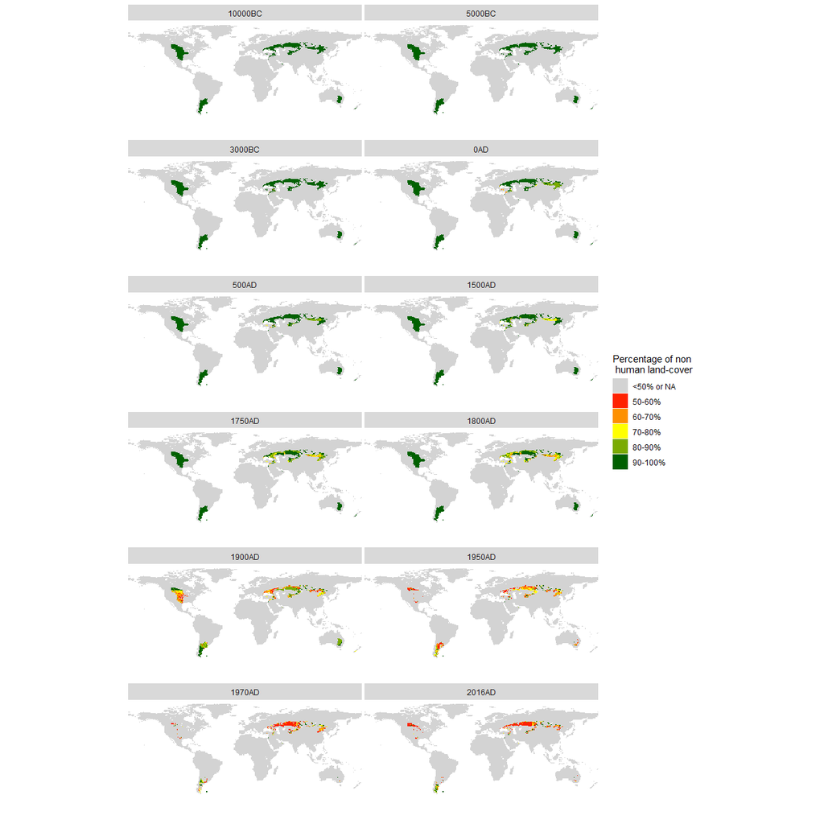

Figure 1. Changes in the extent of temperate grasslands through time. A cell is considered as belonging to a given biome only if less than 50% of its area is covered by human land-cover.

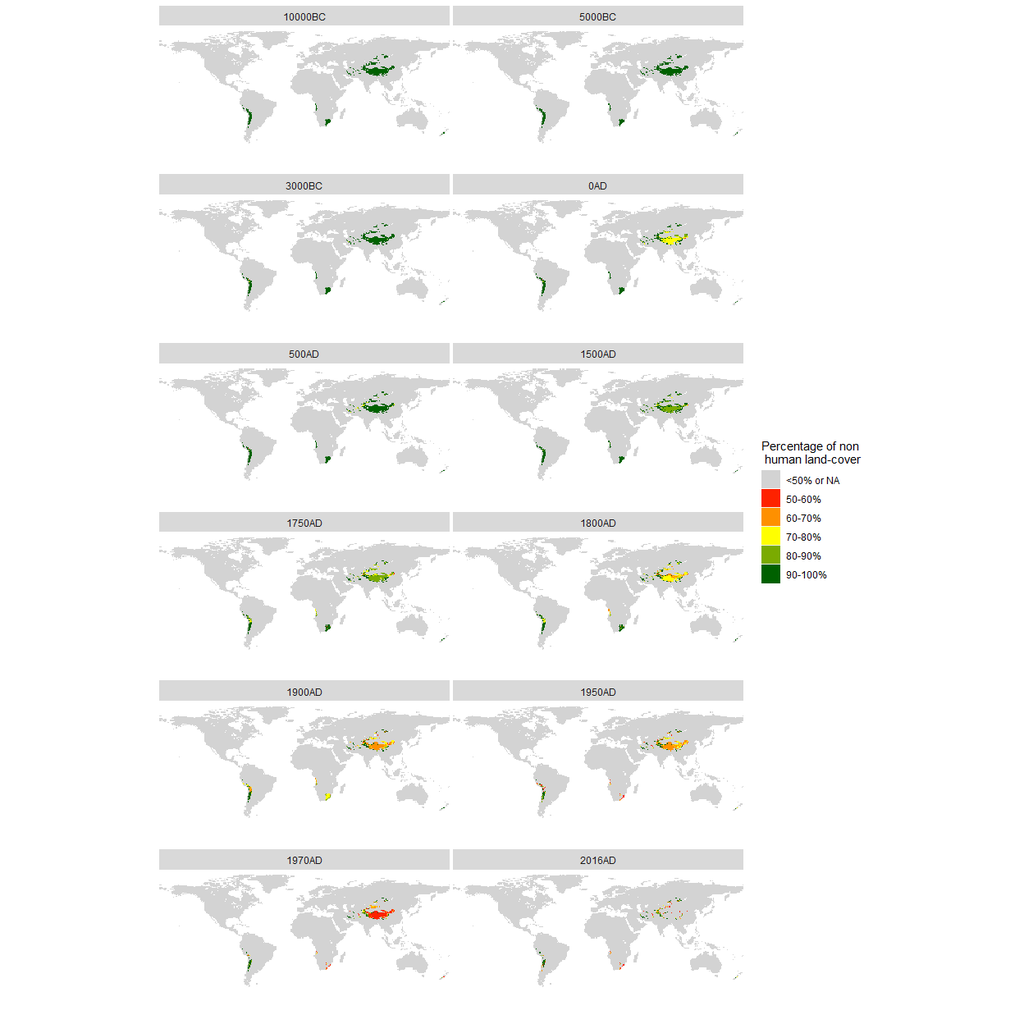

Figure 2. Changes in the extent of montane grasslands through time. A cell is considered as belonging to a given biome only if less than 50% of its area is covered by human land-cover.

## 3.2 Temporal evolution of biomes area through the Holocene

Once the stacked raster containing have been produced for each date, the total area is computed for each biome at each point in time.  
While compiling the stacked raster in not so computationnaly intensive (a few hours), compiling the area of non human land-cover in each cell, for each biome and at each time point is computationnally intensive.  
In order to fasten the process, it can be parallelized (here on a single machine)

```r
# creating a dataframe matching biomes names and numeric code (embedded in the biome raster)
biomes_codes <- attr(raster_biomes@data, "attributes")[[1]]

# Assuming that the stacked raster are stored in "path/to/stacked_raster_folder"
stacked_raster_path <- "path/to/stacked_raster_folder"

rasters <- dir(stacked_raster_path)

# Compiling the area of non human land-cover in each pixel for each biome at each time point
sfInit(parallel=TRUE, cpus=6)
sfExport("raster")
df_area_biomes <- sfAapply(rasters, function(r){
                    raster_area <- area(raster(file.path(raster_path, r)))
                    sapply(seq(16), function(layer){
                        biomes_area <- raster(file.path(raster_path, r), band = layer) * raster_area
                        sum(biomes_area[], na.rm = T)
                        })
                    })
```

```r
# Adding biome names as rownames
rownames(df_area_biomes) <- as.character(biomes_codes$category[-1])

df_area_biomes <- apply(df_area_biomes, 2, function(x){
                        x / df_area_biomes[,grep("10000BC", colnames(df_area_biomes))] *100
                        })


# Transforming the data in long table and adding a year column (using 2016 as present date)
# and removing Mangrove, Waters, Rock and Montane grasslands
df_area_long <- as.data.frame(t(df_area_biomes)) %>%
                    rownames_to_column(var = "year_AD_BC") %>%
                    gather(Biome, Area, -year_AD_BC) %>%
                    mutate(year_AD_BC = gsub("biomes_", "", year_AD_BC)) %>%
                    mutate(year_AD_BC = gsub(".tif", "", year_AD_BC)) %>%
                    mutate(AD_or_BC = substr(year_AD_BC, nchar(year_AD_BC) - 1, nchar(year_AD_BC ))) %>%
                    mutate(year_BP = as.numeric(substr(year_AD_BC, 1, nchar(year_AD_BC) - 2))) %>%
                    mutate(year_BP = year_BP * ifelse(AD_or_BC == "BC", -1, 1) - 2017)# %>%
```

The area of each biomes at each time point is expressed as a percentage of the maximum area of each biome (that is to say at 10000BC, Figure 3)

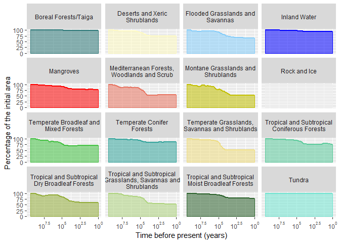

Figure 3. Temporal evolution of biomes area. The biome area for any given point in time is calculated as the sum of cells area not covered by human land-cover, as extracted from the HYDE 3.2 dataset